# Analysis of FitBit Fitness Tracker Data for Bellabeat

## Calories vs Total Step

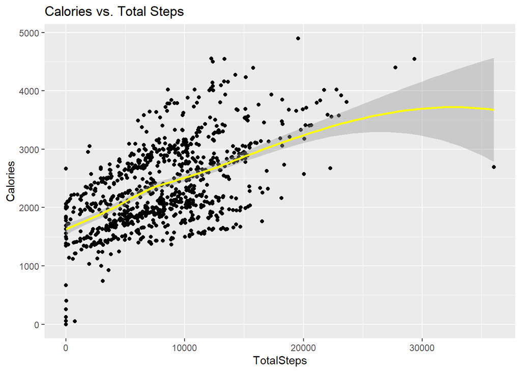

```r
 ggplot(data = daily_activity, aes(x = TotalSteps, y = Calories)) + geom_point() +
 geom_smooth(method = "loess",color = "yellow") + labs(title = "Calories vs. Total Steps") + theme()
```

Check the corelation between Calories & Total Steps

```r
cor.test(daily_activity$TotalSteps, daily_activity$Calories,
 alternative = "greater")
```

```
##
##  Pearson's product-moment correlation
##
## data:  daily_activity$TotalSteps and daily_activity$Calories
## t = 22.472, df = 938, p-value < 2.2e-16
## alternative hypothesis: true correlation is greater than 0
## 95 percent confidence interval:
##  0.5555268 1.0000000
## sample estimates:
##       cor
## 0.5915681
```

#### Description:

There is a statistically significant positive correlation between the total number of steps taken per day (TotalSteps) and the number of calories burned (Calories). The correlation coefficient of 0.5915681 indicates a moderate to strong positive relationship, suggesting that as the number of steps increases, the number of calories burned also increases. This correlation is statistically significant with a very low p-value (< 2.2e-16), allowing us to confidently reject the null hypothesis that there is no correlation in the population. The 95% confidence interval for the correlation ranges from 0.5555268 to 1.0000000, indicating with 95% confidence that the population correlation lies within this range.

These findings suggest that physical activity, as measured by steps taken, is closely linked to energy expenditure, as measured by calories burned. This insight could be valuable for developing targeted health and fitness programs or marketing strategies for products aimed at increasing physical activity and promoting weight loss or fitness.

## Time of Intensities

#### Adds new columns to the hourly_intensities dataset to enhance temporal analysis

```r
# Add Date column formatted from ActivityHour
hourly_intensities$Date <- format(as.Date(hourly_intensities$ActivityHour, format = "%m/%d/%Y"), format = "%m/%d/%Y")

# Parse ActivityHour column to datetime format
hourly_intensities$ActivityHour <- mdy_hms(hourly_intensities$ActivityHour, tz = Sys.timezone())

# Add Time column formatted from ActivityHour
hourly_intensities$Time <- format(hourly_intensities$ActivityHour, format = "%H:%M:%S")

# Add day_of_week column derived from ActivityHour
hourly_intensities$day_of_week <- format(as.Date(hourly_intensities$ActivityHour), "%A")
```

#### Orders the day_of_week column in the hourly_intensities dataset based on predefined levels

```r
hourly_intensities$day_of_week <- ordered(hourly_intensities$day_of_week, levels=c("Sunday", "Monday", "Tuesday", "Wednesday",                                                                                    "Thursday", "Friday", "Saturday"))
```

#### Prepare data for plotting average total intensity over time and by day of the week

```r
extract_data <- hourly_intensities[, c(3,6)]
plot_data <- extract_data %>%
  group_by(Time) %>%
  summarise(avg_TotalIntensity = mean(TotalIntensity))

extract_data2 <- hourly_intensities[, c(3,7)]
plot_data2 <- extract_data2 %>%
  group_by(day_of_week) %>%
  summarise(avg_TotalIntensity = mean(TotalIntensity))
```

#### creates a bar plot using ggplot2 to visualize the average total intensity per hour (avg_TotalIntensity) over different times (Time)

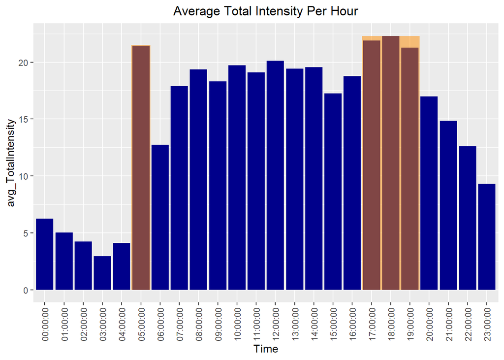

```r
ggplot(data = plot_data, aes(x = Time, y = avg_TotalIntensity)) +
  geom_bar(stat = "identity", fill = "darkblue") +
  labs(title = "Average Total Intensity Per Hour") +
  annotate("rect", xmin = 17.5, ymin = 0, xmax = 20.5, ymax = 22.3,
           fill = "darkorange", alpha = 0.5) + annotate("rect", xmin = 5.5, ymin = 0, xmax = 6.5, ymax = 21.5,
           fill = "darkorange", alpha = 0.5) +
  theme(axis.text.x = element_text(angle = 90, vjust = 0.5),
        plot.title = element_text(hjust = 0.5))
```

```r
#ggsave("time_total_intensity.jpg")
```